# Project Business Statistics: E-news Express

**Marks: 60**

## Define Problem Statement and Objectives

E-news Express believes that their decline in monthly subscribers is because the webpage is not well-designed and doesn't recommend content to keep customer engaged long enough to subscribe. The E-news Express design team has created a new landing page for their website in the hopes that it will be more effective in engaging customers and getting them to subscribe. Our data science team has conducted an A/B test and we will be perfoming the statistical analysis to answer four key questions along the way:

1. Do the users spend more time on the new landing page than on the existing landing page?
2. Is the conversion rate (the proportion of users who visit the landing page and get converted) for the new page greater than the conversion rate for the old page?
3. Does the converted status depend on the preferred language?
4. Is the time spent on the new page the same for the different language users?

## Import all the necessary libraries

```python
# import libraries for data manipulation
import pandas as pd
import numpy as np

# import libraries for data visualization
import matplotlib.pyplot as plt
import seaborn as sns
%matplotlib inline

# import libraries for stats
import scipy
import scipy.stats as stats
```

## Reading the Data into a DataFrame

```python
# connect to google drive
from google.colab import drive
drive.mount('/content/drive')
```

```python
# read in csv file to create df
df = pd.read_csv('/content/drive/MyDrive/Module 1 - Intro to Python/abtest.csv')
```

## Explore the dataset and extract insights using Exploratory Data Analysis

- Data Overview
  - Viewing the first and last few rows of the dataset
  - Checking the shape of the dataset
  - Getting the statistical summary for the variables
- Check for missing values
- Check for duplicates

**Data Dictionary:**

- user_id - Unique user ID of the person visiting the website
- group - Whether the user belongs to the first group (control) or the second group (treatment)
- landing_page - Whether the landing page is new or old
- time_spent_on_the_page - Time (in minutes) spent by the user on the landing page
- converted - Whether the user gets converted to a subscriber of the news portal or not
- language_preferred - Language chosen by the user to view the landing page

```python
# view the first 5 rows of data
df.head(5)
```

|  | user_id | group | landing_page | time_spent_on_the_page | converted | language_preferred |
| --- | --- | --- | --- | --- | --- | --- |
| 0 | 546592 | control | old | 3.48 | no | Spanish |
| 1 | 546468 | treatment | new | 7.13 | yes | English |
| 2 | 546462 | treatment | new | 4.40 | no | Spanish |
| 3 | 546567 | control | old | 3.02 | no | French |
| 4 | 546459 | treatment | new | 4.75 | yes | Spanish |

```python
# view the last 5 rows of data
df.tail(5)
```

|  | user_id | group | landing_page | time_spent_on_the_page | converted | language_preferred |
| --- | --- | --- | --- | --- | --- | --- |
| 95 | 546446 | treatment | new | 5.15 | no | Spanish |
| 96 | 546544 | control | old | 6.52 | yes | English |
| 97 | 546472 | treatment | new | 7.07 | yes | Spanish |
| 98 | 546481 | treatment | new | 6.20 | yes | Spanish |
| 99 | 546483 | treatment | new | 5.86 | yes | English |

```python
# check the number of rows & columns
df.shape
```

```
(100, 6)
```

Observation: There are exactly 100 rows, which match the nuimber of observations we should see.

```python
 # check data types & nulls
 df.info()
```

```
<class 'pandas.core.frame.DataFrame'>
RangeIndex: 100 entries, 0 to 99
Data columns (total 6 columns):
 #   Column                  Non-Null Count  Dtype
---  ------                  --------------  -----
 0   user_id                 100 non-null    int64
 1   group                   100 non-null    object
 2   landing_page            100 non-null    object
 3   time_spent_on_the_page  100 non-null    float64
 4   converted               100 non-null    object
 5   language_preferred      100 non-null    object
dtypes: float64(1), int64(1), object(4)
memory usage: 4.8+ KB
```

Observation: There are no null values in the dataset.

```python
# change the data type for user_id from int to object so we can get unique counts
df['user_id']=df['user_id'].astype(str)

# check to make sure the data type changed
df['user_id'].dtype
```

```
dtype('O')
```

```python
# double check for null values
df.isnull().sum()
```

```
user_id                   0
group                     0
landing_page              0
time_spent_on_the_page    0
converted                 0
language_preferred        0
dtype: int64
```

```python
# statistical summary for each variable
df.describe(include='all')
```

|  | user_id | group | landing_page | time_spent_on_the_page | converted | language_preferred |
| --- | --- | --- | --- | --- | --- | --- |
| count | 100 | 100 | 100 | 100.000000 | 100 | 100 |
| unique | 100 | 2 | 2 | NaN | 2 | 3 |
| top | 546592 | control | old | NaN | yes | Spanish |
| freq | 1 | 50 | 50 | NaN | 54 | 34 |
| mean | NaN | NaN | NaN | 5.377800 | NaN | NaN |
| std | NaN | NaN | NaN | 2.378166 | NaN | NaN |
| min | NaN | NaN | NaN | 0.190000 | NaN | NaN |
| 25% | NaN | NaN | NaN | 3.880000 | NaN | NaN |
| 50% | NaN | NaN | NaN | 5.415000 | NaN | NaN |
| 75% | NaN | NaN | NaN | 7.022500 | NaN | NaN |
| max | NaN | NaN | NaN | 10.710000 | NaN | NaN |

Observation: There is only one numerical variable, but we can still use this to see that there are 100 unique users (no duplicates), 2 unique groups, and 2 unique landing pages, which is exactly what we would expect. Now let's just check the unique values for each variable to make sure the data isn't dirty.

```python
# check the unique values for each variable
df['user_id'].unique()
```

```
array(['546592', '546468', '546462', '546567', '546459', '546558',
       '546448', '546581', '546461', '546548', '546588', '546546',
       '546491', '546478', '546578', '546466', '546443', '546555',
       '546493', '546549', '546560', '546584', '546450', '546475',
       '546456', '546455', '546469', '546586', '546471', '546575',
       '546464', '546556', '546585', '546577', '546587', '546552',
       '546551', '546557', '546487', '546589', '546559', '546570',
       '546489', '546453', '546488', '546565', '546460', '546458',
       '546492', '546473', '546554', '546457', '546479', '546576',
       '546482', '546563', '546569', '546454', '546562', '546574',
       '546470', '546467', '546572', '546590', '546553', '546445',
       '546545', '546582', '546484', '546579', '546568', '546476',
       '546452', '546444', '546591', '546583', '546573', '546485',
       '546486', '546547', '546490', '546449', '546463', '546580',
       '546571', '546564', '546465', '546480', '546447', '546561',
       '546477', '546451', '546566', '546474', '546550', '546446',
       '546544', '546472', '546481', '546483'], dtype=object)
```

```python
df['group'].unique()
```

```
array(['control', 'treatment'], dtype=object)
```

```python
df['landing_page'].unique()
```

```
array(['old', 'new'], dtype=object)
```

```python
df['time_spent_on_the_page'].unique()
```

```
array([ 3.48,  7.13,  4.4 ,  3.02,  4.75,  5.28,  5.25,  6.53, 10.71,
        2.08,  6.21,  2.58,  5.86,  6.03,  8.72,  6.27,  8.73,  0.4 ,
       10.3 ,  3.88,  2.66,  7.03,  3.65,  7.02,  6.18,  4.39,  9.49,
        4.05,  7.81,  4.28,  5.41,  3.52,  5.39,  4.52,  4.46,  8.5 ,
        3.13,  6.04,  1.65,  0.19,  8.46,  1.92,  7.16,  3.91,  8.02,
        5.37,  7.23,  8.08, 10.5 ,  0.22,  5.65,  6.47,  4.71,  6.41,
        0.93,  1.81,  8.3 ,  7.4 ,  9.15,  6.01,  6.79,  4.18,  5.47,
        5.96,  7.27,  6.6 ,  6.7 ,  2.23,  5.42,  5.08,  7.46,  4.87,
        6.57,  1.44,  9.12,  3.21,  4.68,  5.26,  5.74,  2.9 ,  4.3 ,
        0.91,  6.71,  3.68,  3.3 ,  5.4 ,  8.47,  8.35,  4.94,  3.05,
        5.15,  6.52,  7.07,  6.2 ])
```

```python
df['converted'].unique()
```

```
array(['no', 'yes'], dtype=object)
```

```python
df['language_preferred'].unique()
```

```
array(['Spanish', 'English', 'French'], dtype=object)
```

### Univariate Analysis

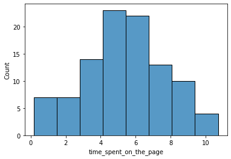

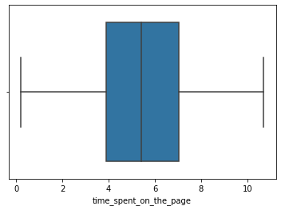

```python
# visualize the one numerical variable first
sns.histplot(data=df, x='time_spent_on_the_page')
plt.show()
sns.boxplot(data=df, x='time_spent_on_the_page')
plt.show()
```

Observation: We can see that about 50% of visitors (regardless of which site they were shown) spent between 4-7 minutes on the page. In the bivariate analysis, we will want to explore what this looks like for each of the two versions of the page.

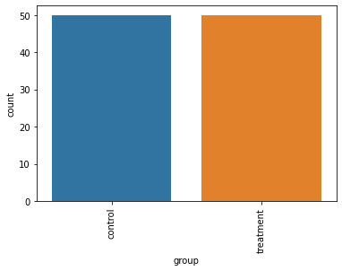

```python
# now visualize the categorical variables using countplots - skipping user ID since we know it's 100 unique values
sns.countplot(data=df, x='group')
plt.xticks(rotation=90);
```

Observation: This validates that 50 users were shown the control site and 50 were shown the treatment site.

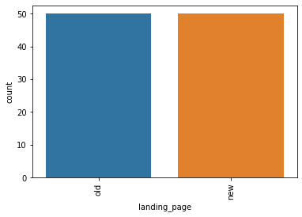

```python
sns.countplot(data=df, x='landing_page')
plt.xticks(rotation=90);
```

Observation: This also validates that 50 users were shown the old site and 50 the new.

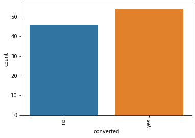

```python
sns.countplot(data=df,x='converted')
plt.xticks(rotation=90);
```

Observation: We can see that slightly more than half of the visitors to the site subscribed. However, we don't know if the majoirty were from the old site or the new site yet.

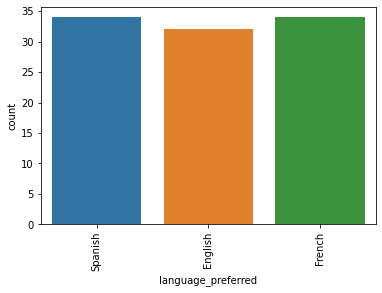

```python
sns.countplot(data=df,x='language_preferred')
plt.xticks(rotation=90);
```

Observation: Most visitors actually spoke either Spanish or French over English.

### Bivariate Analysis

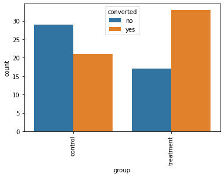

```python
# compare the group to the conversion rate
sns.countplot(data=df, x='group', hue='converted')
plt.xticks(rotation=90);
```

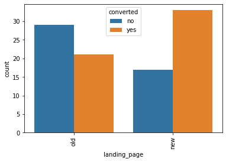

```python
# compare the landing page a user was shown to conversion
sns.countplot(data=df, x='landing_page', hue='converted')
plt.xticks(rotation=90);
```

Observation: We can conclude the data is accurate since those in the control group should've been shown the old page and it seems that they were as the numbers are aligned for both charts. It appears that more users in the control group did not subscribe whereas more users in the treatment group seeing the new page did subscribe.

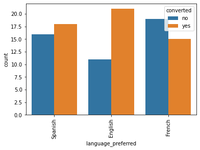

```python
# conversion compared to language spoken
sns.countplot(data=df,x='language_preferred', hue='converted')
plt.xticks(rotation=90);
```

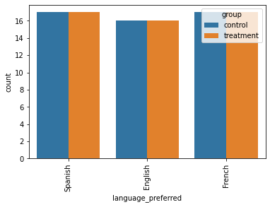

```python
# language spoken compared to group assigned
sns.countplot(data=df,x='language_preferred', hue='group')
plt.xticks(rotation=90);
```

Observation: It appears that Spanish and especially English speakers were more likely to subscribe versus French speakers. At first I thought possibly more English speakers were assigned to the treatment group and perhaps that is why, but actually it was a 50%/50% split across all languages, even though there are less overall english speakers.

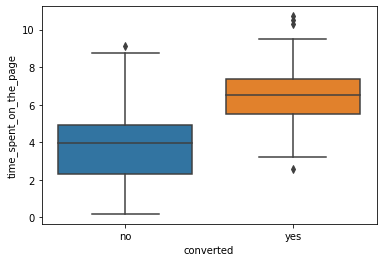

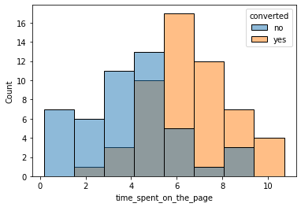

```python
# compare the time spent on the page to conversion stats
sns.boxplot(data=df,x='converted',y='time_spent_on_the_page')
plt.show()

sns.histplot(data=df, x='time_spent_on_the_page', hue='converted')
plt.show()
```

Observation: Visitors who spent more time on the page were more likely to subscribe.

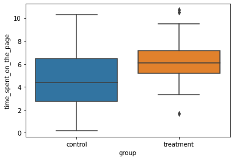

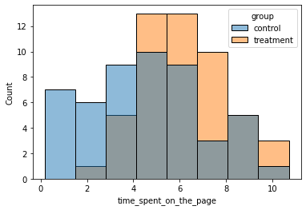

```python
# compare the time spent on the page to group
sns.boxplot(data=df,x='group',y='time_spent_on_the_page')
plt.show()

sns.histplot(data=df, x='time_spent_on_the_page', hue='group')
plt.show()
```

Observation: ~75% of visitors in the treatment group spent 5 or more minutes on the page. 75% of visitors in the control group spent less than 7 minutes on the page. For the most part other than a few outliers, the visitors in the treatment group spent more than 3 minutes on the page.

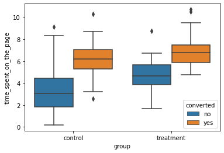

```python
# compare the time spent on the page to conversion stats & group
sns.boxplot(data=df,x='group',y='time_spent_on_the_page',hue='converted')
plt.show()
```

Obersvation: For both groups, the more time a visitor spent on the page, the more likely they were to subscribe.

## 1. Do the users spend more time on the new landing page than the existing landing page?

### Perform Visual Analysis

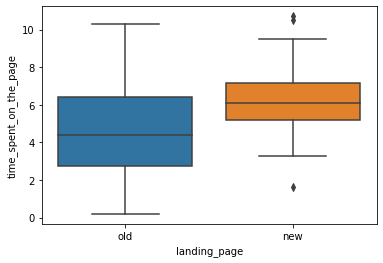

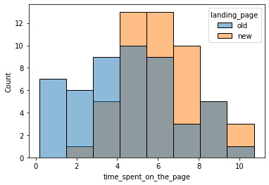

```python
# compare the time spent on the page to the site shown
sns.boxplot(data=df,x='landing_page',y='time_spent_on_the_page')
plt.show()

sns.histplot(data=df, x='time_spent_on_the_page', hue='landing_page')
plt.show()
```

```python
df.groupby(['landing_page'])['time_spent_on_the_page'].mean()
```

```
landing_page
new    6.2232
old    4.5324
Name: time_spent_on_the_page, dtype: float64
```

Observation: Yes, it appears that visitors spend an average of ~1.7 minutes more on the new landing page than the old landing page.

### Step 1: Define the null and alternate hypotheses

We will test the null hypothesis

> $H_0:\mu_1=\mu_2$

against the alternate hypothesis

> $H_a:\mu_1>\mu_2$

Where $\mu_1$ is the mean time spent on the new landing page and $\mu_2$ is the mean time spent on the old landing page.

### Step 2: Select Appropriate test

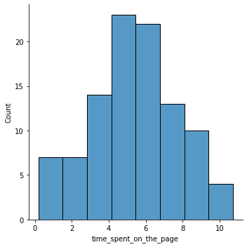

```python
# plot the distribution plot of time spent on the page
sns.displot(df.time_spent_on_the_page)
plt.show()
```

Observation: The distribution seems fairly normal

```python
# find the sample standard deviations for the two samples
df.groupby(['landing_page'])['time_spent_on_the_page'].std()
```

```
landing_page
new    1.817031
old    2.581975
Name: time_spent_on_the_page, dtype: float64
```

We will use a two sample T-test because it meets the following criteria:

- Continuous data - The time spent on the page is measured on a continuous scale.
- Normally distributed populations or Sample sizes > 30 - Since the sample sizes are greater than 30, Central Limit Theorem states that the distribution of sample means will be normal.
- Independent populations - As we are taking samples for two different channels, the two samples are from two independent populations.
- Unequal population standard deviations - Since the sample stds are different, we can assume the population stds are also different.
- Random sampling from the population - the collected sample is a simple random sample.

### Step 3: Decide the significance level

We have been told to use a 5% significance level so will set alpha as 0.05

### Step 4: Collect and prepare data

```python
# create separate variables to store the two landing pages
old_landing_page = df[df['landing_page']=='old']['time_spent_on_the_page']
new_landing_page = df[df['landing_page']=='new']['time_spent_on_the_page']
```

### Step 5: Calculate the p-value

```python
# import the required functions
from scipy.stats import ttest_ind

# find the p-value
test_stat, p_value = ttest_ind(new_landing_page, old_landing_page, equal_var = False, alternative = 'greater')
print('The p-value is ', p_value)
```

```
The p-value is  0.0001392381225166549
```

### Step 6: Compare the p-value with $\alpha$

```python
# check to see if p-value is less than alpha
p_value < 0.05
```

```
True
```

Since the p-value of 0.0001 is much lower than the level of significance of 0.05, so we reject the null hypothesis.

### Step 7: Draw inference

We have enough statistical evidence to reject the null hypothesis and can conclude that the mean time visitors spent on the new landing page is higher than the time visitors spent on the old landing page.

**A similar approach can be followed to answer the other questions.**